# Coursework Report

*N* removed NAs: 3

*N* removed typo: 1

*N* removed <18: 21

*N* total clean: 126

| Group | *N* | *M*<sub>age</sub> | *M*<sub>rating</sub> |
| --- | --- | --- | --- |
| Control | 59 | 21.10 | 6.50 |
| Experim | 67 | 20.97 | 5.28 |

**Main analysis results**

*t*(124) = 8.26, *p* < .001

[interactive chart not shown]

[figure not shown]

[interactive chart not shown]

# Coursework Report

Analysing Data, Spring 2020

# Methods

## Design

This study has been designed to test the hypothesis that women find men more sexually attractive and desirable when viewed with the colour red. Therefore, as this is a replication of the study by Elliot et al. (2010), the same study design will be used. This is a between subjects design so participants were randomly allocated either the control or experimental condition. In the control condition, participants were shown a black and white picture of a typically attractive man on a white 8.5inch x 11inch piece of paper, on a white background. The picture was shown for 5 seconds. The experimental condition followed the same procedure but used a red background instead of the grey one, therefore meaning background colour was the independent categorical variable. Once the participants had seen the picture, they were asked three questions, (1) “How attractive do you think this person is?” (2) “How pleasant is this person to look at?” and (3) “If I were to meet this person in the picture face to face, I would think he’s attractive.” All of these were answered on a 9-point scale from 1, being not attractive at all, to 9, being extremely attractive. All three of these scores will be averaged for each participant to give them one composite score. This was done to measure attractiveness, which is the continuous variable. The operational hypothesis for this study is that the participants in the experimental condition, who are viewing the red pictures, will, on average, give higher average scores on the 9 point scale (from 1-9), than the participants in the control condition, who viewed the picture with the white background. The statistical analysis that will be used to analyse this is the t-test.

# Results

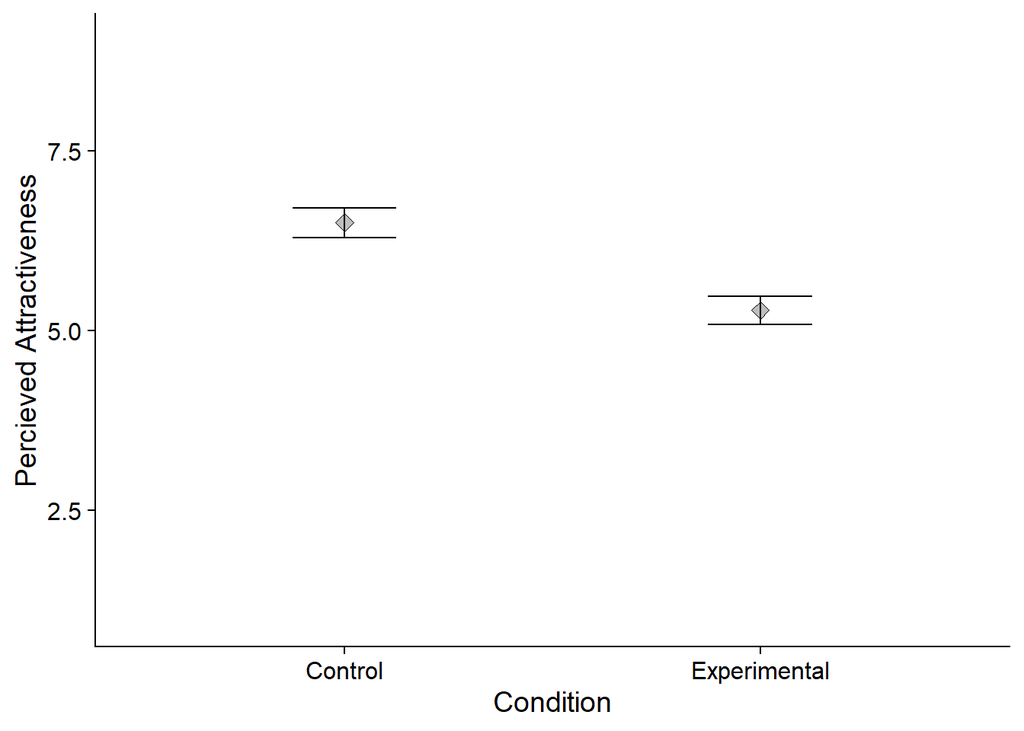

Figure 1: The composite scores in the control and experimental condition on perceived attractiveness

```
##
##  Two Sample t-test
##
## data:  attractiveness_comp by GROUP
## t = 8.2604, df = 124, p-value = 0.0000000000001853
## alternative hypothesis: true difference in means is not equal to 0
## 95 percent confidence interval:
##  0.9265853 1.5105510
## sample estimates:
##      mean in group Control mean in group Experimental
##                   6.497175                   5.278607
```

Figure 2: T-test of composite mean scores of experimental and control conditions